# Assignment 8

Laura Fusi

2023-04-28

```r
suppressPackageStartupMessages({
  library(GenomicRanges)
  library(Biostrings)
  library(AnnotationHub)
  library(epiwraps)
  library(motifmatchr)
  library(MotifDb)
  library(universalmotif)
  library(sechm)
  library(BiocParallel)
  library(ggplot2)
  library(chromVAR) # for motif accessibility estimation
  library(SummarizedExperiment) # data structure
  library(limma) # for statistical analysis
  library(BSgenome.Mmusculus.UCSC.mm10)
  library(stats)
})
```

```
## See system.file("LICENSE", package="MotifDb") for use restrictions.
```

```r
# to control multithreading, unix users can use:
# register(MulticoreParam(4))
# for windows users, rather one of the following:
# register(SerialParam())
register(SnowParam(2))
```

# Download ATAC-seq peak counts in the hippocampus upon stress (subset of the original data, already in SummarizedExperiment format) :

- https://ethz-ins.org/content/mouse_mm38_hippocampus.peakCounts.SE.rds

```r
# Download the file and read it
options(timeout=6000)
download.file("https://ethz-ins.org/content/mouse_mm38_hippocampus.peakCounts.SE.rds", "mouse_mm38_hippocampus.peakCounts.SE.rds", mode="wb")
```

```r
peak_counts_SE <- readRDS("mouse_mm38_hippocampus.peakCounts.SE.rds")
peak_counts_SE
```

```
## class: RangedSummarizedExperiment
## dim: 20660 12
## metadata(0):
## assays(1): counts
## rownames: NULL
## rowData names(0):
## colnames(12): Control_female_GSM6041841.bam
##   Control_female_GSM6041842.bam ... FSS_male_GSM6041857.bam
##   FSS_male_GSM6041858.bam
## colData names(1): depth
```

```r
# import genome
#ah <- AnnotationHub(localHub=TRUE)
#genome <- ah[["AH68356"]]
#Biostrings::writeXStringSet(rtracklayer::import(genome), "genome.fa")
genome_fa <- Rsamtools::FaFile("genome.fa")
```

# Using this object, perform a chromVAR motif analysis, and run 2 differential motif accessibility analyses, respectively:

```r
# Get the database of motifs
motifs <- query(MotifDb, c("HOCOMOCOv10", "Mmusculus"))
motifs <- do.call(TFBSTools::PWMatrixList, setNames(
           universalmotif::convert_motifs(motifs, class="TFBSTools-PWMatrix"),
           mcols(motifs)$providerName))
```

## comparing stressed (denoted ‘FSS’ – forced swim stress) and control animals

```r
genome <- BSgenome.Mmusculus.UCSC.mm10::BSgenome.Mmusculus.UCSC.mm10 # because I had windows-related problems with the other genome
seqlevelsStyle(peak_counts_SE) = "UCSC"
se <- suppressWarnings(chromVAR::addGCBias(peak_counts_SE, genome=genome))
moi <- suppressWarnings(motifmatchr::matchMotifs(motifs, subject=se, genome=genome))

se
```

```
## class: RangedSummarizedExperiment
## dim: 20660 12
## metadata(0):
## assays(1): counts
## rownames: NULL
## rowData names(1): bias
## colnames(12): Control_female_GSM6041841.bam
##   Control_female_GSM6041842.bam ... FSS_male_GSM6041857.bam
##   FSS_male_GSM6041858.bam
## colData names(1): depth
```

```r
colData(se)$condition <- c("CTRL","CTRL","CTRL","CTRL","CTRL","CTRL","FSS","FSS","FSS","FSS","FSS","FSS")
se$condition <- c("CTRL","CTRL","CTRL","CTRL","CTRL","CTRL","FSS","FSS","FSS","FSS","FSS","FSS")
colData(se)
```

```
## DataFrame with 12 rows and 2 columns
##                                   depth   condition
##                               <numeric> <character>
## Control_female_GSM6041841.bam  73170149        CTRL
## Control_female_GSM6041842.bam  93995034        CTRL
## Control_female_GSM6041843.bam  40167775        CTRL
## Control_male_GSM6041844.bam    70491005        CTRL
## Control_male_GSM6041845.bam    84985977        CTRL
## ...                                 ...         ...
## FSS_female_GSM6041854.bam      73674456         FSS
## FSS_female_GSM6041855.bam      49285912         FSS
## FSS_male_GSM6041856.bam        82385764         FSS
## FSS_male_GSM6041857.bam        68623011         FSS
## FSS_male_GSM6041858.bam        81801232         FSS
```

```r
rowRanges(se)$test <- 3
rowRanges(se)
```

```
## GRanges object with 20660 ranges and 2 metadata columns:
##           seqnames            ranges strand |      bias      test
##              <Rle>         <IRanges>  <Rle> | <numeric> <numeric>
##       [1]     chr1   3012609-3012858      * |     0.348         3
##       [2]     chr1   3094941-3095190      * |     0.424         3
##       [3]     chr1   3113634-3113883      * |     0.448         3
##       [4]     chr1   3119522-3119771      * |     0.448         3
##       [5]     chr1   3119880-3120129      * |     0.432         3
##       ...      ...               ...    ... .       ...       ...
##   [20656]     chrY 90744317-90744566      * |     0.636         3
##   [20657]     chrY 90744689-90744938      * |     0.544         3
##   [20658]     chrY 90761326-90761575      * |     0.640         3
##   [20659]     chrY 90804984-90805233      * |     0.472         3
##   [20660]     chrY 90808700-90808949      * |     0.416         3
##   -------
##   seqinfo: 30 sequences from an unspecified genome; no seqlengths
```

```r
#moi <- motifmatchr::matchMotifs(motifs, subject=peak_counts_SE, genome=genome_fa)
dev <- chromVAR::computeDeviations(object = se, annotations=moi,
                                   background_peaks=getBackgroundPeaks(se, niterations=1000))
dev
```

```
## class: chromVARDeviations
## dim: 426 12
## metadata(0):
## assays(2): deviations z
## rownames(426): AHR_MOUSE.H10MO.B AIRE_MOUSE.H10MO.C ...
##   ZN148_MOUSE.H10MO.D ZN423_MOUSE.H10MO.D
## rowData names(3): name fractionMatches fractionBackgroundOverlap
## colnames(12): Control_female_GSM6041841.bam
##   Control_female_GSM6041842.bam ... FSS_male_GSM6041857.bam
##   FSS_male_GSM6041858.bam
## colData names(2): depth condition
```

```r
colData(dev)
```

```
## DataFrame with 12 rows and 2 columns
##                                   depth   condition
##                               <numeric> <character>
## Control_female_GSM6041841.bam  73170149        CTRL
## Control_female_GSM6041842.bam  93995034        CTRL
## Control_female_GSM6041843.bam  40167775        CTRL
## Control_male_GSM6041844.bam    70491005        CTRL
## Control_male_GSM6041845.bam    84985977        CTRL
## ...                                 ...         ...
## FSS_female_GSM6041854.bam      73674456         FSS
## FSS_female_GSM6041855.bam      49285912         FSS
## FSS_male_GSM6041856.bam        82385764         FSS
## FSS_male_GSM6041857.bam        68623011         FSS
## FSS_male_GSM6041858.bam        81801232         FSS
```

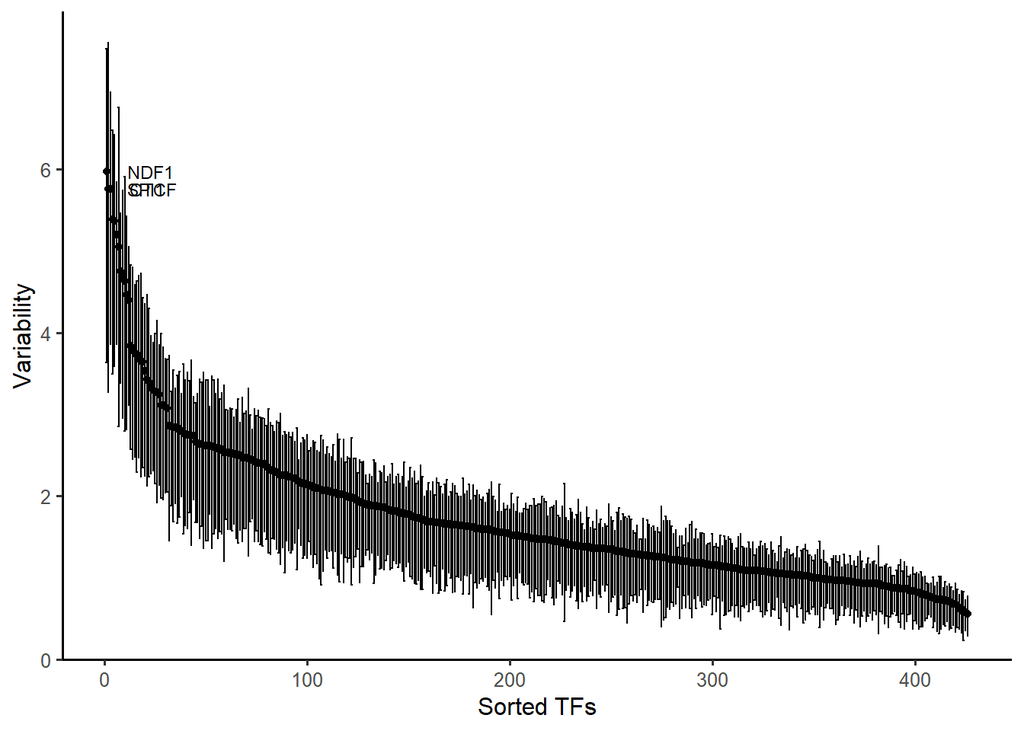

```r
variability <- computeVariability(dev)
plotVariability(variability)
```

```r
head(assays(dev)$z)
```

```
##                    Control_female_GSM6041841.bam Control_female_GSM6041842.bam
## AHR_MOUSE.H10MO.B                     -0.5361128                     0.1976590
## AIRE_MOUSE.H10MO.C                     0.0789946                    -0.3768223
## ALX1_MOUSE.H10MO.B                     0.5504443                     0.2145700
## ANDR_MOUSE.H10MO.B                    -5.8997008                    -2.1782540
## AP2A_MOUSE.H10MO.A                     0.2794774                    -1.9660713
## AP2B_MOUSE.H10MO.B                     1.9275433                    -0.5816288
##                    Control_female_GSM6041843.bam Control_male_GSM6041844.bam
## AHR_MOUSE.H10MO.B                      0.3791682                  -0.2769308
## AIRE_MOUSE.H10MO.C                    -2.4389831                   1.8223434
## ALX1_MOUSE.H10MO.B                    -0.1592780                  -0.3234646
## ANDR_MOUSE.H10MO.B                    -1.4002781                  -2.5775532
## AP2A_MOUSE.H10MO.A                    -0.3853788                   2.0289294
## AP2B_MOUSE.H10MO.B                    -1.1400785                   1.8472795
##                    Control_male_GSM6041845.bam Control_male_GSM6041846.bam
## AHR_MOUSE.H10MO.B                   0.59067104                 -0.73088306
## AIRE_MOUSE.H10MO.C                 -0.02015679                 -0.26769110
## ALX1_MOUSE.H10MO.B                  0.41595243                 -1.26873991
## ANDR_MOUSE.H10MO.B                 -3.53486628                 -4.53815109
## AP2A_MOUSE.H10MO.A                  1.64742314                 -0.00649364
## AP2B_MOUSE.H10MO.B                 -1.01365802                  0.59125899
##                    FSS_female_GSM6041853.bam FSS_female_GSM6041854.bam
## AHR_MOUSE.H10MO.B                  0.8790907                -0.2637721
## AIRE_MOUSE.H10MO.C                 1.1243289                 1.3678759
## ALX1_MOUSE.H10MO.B                -0.7545798                 0.8011698
## ANDR_MOUSE.H10MO.B                 7.3019211                 0.1858289
## AP2A_MOUSE.H10MO.A                 1.1592400                -1.6476264
## AP2B_MOUSE.H10MO.B                 0.8604887                -0.2589021
##                    FSS_female_GSM6041855.bam FSS_male_GSM6041856.bam
## AHR_MOUSE.H10MO.B                 -1.2894820              -1.0357124
## AIRE_MOUSE.H10MO.C                 0.7383203               1.5977367
## ALX1_MOUSE.H10MO.B                 0.1198539               0.7407682
## ANDR_MOUSE.H10MO.B                 6.1448464               4.4548167
## AP2A_MOUSE.H10MO.A                 0.3678046               0.6922644
## AP2B_MOUSE.H10MO.B                 0.2261522               1.5546925
##                    FSS_male_GSM6041857.bam FSS_male_GSM6041858.bam
## AHR_MOUSE.H10MO.B                0.5842681              0.05595945
## AIRE_MOUSE.H10MO.C               1.4791094              0.27696513
## ALX1_MOUSE.H10MO.B              -0.3836420             -0.32699298
## ANDR_MOUSE.H10MO.B               6.1627693              4.96391692
## AP2A_MOUSE.H10MO.A               1.0925639             -0.07537734
## AP2B_MOUSE.H10MO.B               0.8511793             -0.62575462
```

```r
assays(dev)$norm <- scale(assays(dev)$z)
dev
```

```
## class: chromVARDeviations
## dim: 426 12
## metadata(0):
## assays(3): deviations z norm
## rownames(426): AHR_MOUSE.H10MO.B AIRE_MOUSE.H10MO.C ...
##   ZN148_MOUSE.H10MO.D ZN423_MOUSE.H10MO.D
## rowData names(3): name fractionMatches fractionBackgroundOverlap
## colnames(12): Control_female_GSM6041841.bam
##   Control_female_GSM6041842.bam ... FSS_male_GSM6041857.bam
##   FSS_male_GSM6041858.bam
## colData names(2): depth condition
```

```r
# differential analysis
dev$condition
```

```
##  [1] "CTRL" "CTRL" "CTRL" "CTRL" "CTRL" "CTRL" "FSS"  "FSS"  "FSS"  "FSS"
## [11] "FSS"  "FSS"
```

```r
# if needed, we can specify the baseline condition, by default it's the first in alphabetical order
dev$condition <- factor(dev$condition)
dev$condition <- relevel(dev$condition, "CTRL")
mm <- model.matrix(~dev$condition)

fit <- eBayes(lmFit(assays(dev)$norm, mm))
res <- as.data.frame(topTable(fit, coef="dev$conditionFSS", number = Inf))
head(res)
```

```
##                          logFC     AveExpr         t      P.Value   adj.P.Val
## ANDR_MOUSE.H10MO.B   4.4322143  0.38018303  7.077599 3.662803e-06 0.001560354
## GCR_MOUSE.H10MO.C    2.9428224  0.35239064  5.680024 4.288145e-05 0.009133749
## PRGR_MOUSE.H10MO.C   1.9598034  0.03990862  3.405973 3.886776e-03 0.551922206
## MSX2_MOUSE.H10MO.D   1.0765262  0.09285006  2.841555 1.233091e-02 0.999237039
## NR1I3_MOUSE.H10MO.S  0.7933134  0.10602012  2.411347 2.910215e-02 0.999237039
## HIF1A_MOUSE.H10MO.A -0.8643263 -0.17346765 -2.290597 3.681337e-02 0.999237039
##                             B
## ANDR_MOUSE.H10MO.B   4.425775
## GCR_MOUSE.H10MO.C    2.281476
## PRGR_MOUSE.H10MO.C  -1.806177
## MSX2_MOUSE.H10MO.D  -2.853126
## NR1I3_MOUSE.H10MO.S -3.618820
## HIF1A_MOUSE.H10MO.A -3.825173
```

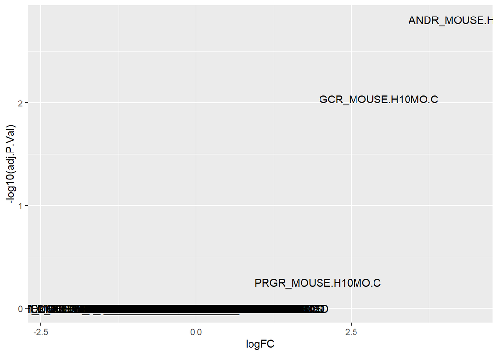

```r
res$TF <- row.names(res)
ggplot(res, aes(logFC, -log10(adj.P.Val), label=TF)) + geom_text()
```

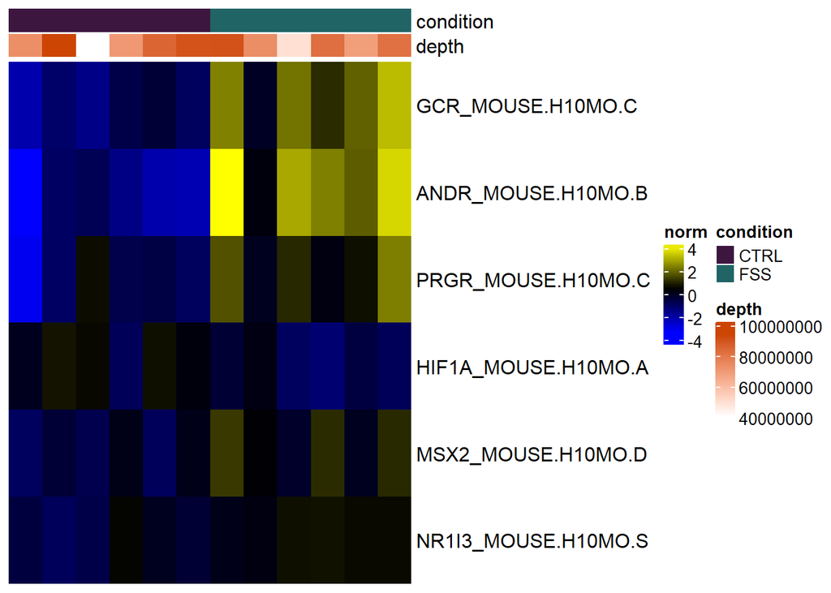

```r
sechm(dev, features = head(row.names(res)), assayName="norm", top_annotation = c("condition", "depth"))
```

## comparing male and female animals

```r
genome <- BSgenome.Mmusculus.UCSC.mm10::BSgenome.Mmusculus.UCSC.mm10 # because I had windows-related problems with the other genome
seqlevelsStyle(peak_counts_SE) = "UCSC"
se <- suppressWarnings(chromVAR::addGCBias(peak_counts_SE, genome=genome))
moi <- suppressWarnings(motifmatchr::matchMotifs(motifs, subject=se, genome=genome))

se
```

```
## class: RangedSummarizedExperiment
## dim: 20660 12
## metadata(0):
## assays(1): counts
## rownames: NULL
## rowData names(1): bias
## colnames(12): Control_female_GSM6041841.bam
##   Control_female_GSM6041842.bam ... FSS_male_GSM6041857.bam
##   FSS_male_GSM6041858.bam
## colData names(1): depth
```

```r
colData(se)$condition <- c("F","F","F","M","M","M","F","F","F","M","M","M")
se$condition <- c("F","F","F","M","M","M","F","F","F","M","M","M")
colData(se)
```

```
## DataFrame with 12 rows and 2 columns
##                                   depth   condition
##                               <numeric> <character>
## Control_female_GSM6041841.bam  73170149           F
## Control_female_GSM6041842.bam  93995034           F
## Control_female_GSM6041843.bam  40167775           F
## Control_male_GSM6041844.bam    70491005           M
## Control_male_GSM6041845.bam    84985977           M
## ...                                 ...         ...
## FSS_female_GSM6041854.bam      73674456           F
## FSS_female_GSM6041855.bam      49285912           F
## FSS_male_GSM6041856.bam        82385764           M
## FSS_male_GSM6041857.bam        68623011           M
## FSS_male_GSM6041858.bam        81801232           M
```

```r
rowRanges(se)$test <- 3
rowRanges(se)
```

```
## GRanges object with 20660 ranges and 2 metadata columns:
##           seqnames            ranges strand |      bias      test
##              <Rle>         <IRanges>  <Rle> | <numeric> <numeric>
##       [1]     chr1   3012609-3012858      * |     0.348         3
##       [2]     chr1   3094941-3095190      * |     0.424         3
##       [3]     chr1   3113634-3113883      * |     0.448         3
##       [4]     chr1   3119522-3119771      * |     0.448         3
##       [5]     chr1   3119880-3120129      * |     0.432         3
##       ...      ...               ...    ... .       ...       ...
##   [20656]     chrY 90744317-90744566      * |     0.636         3
##   [20657]     chrY 90744689-90744938      * |     0.544         3
##   [20658]     chrY 90761326-90761575      * |     0.640         3
##   [20659]     chrY 90804984-90805233      * |     0.472         3
##   [20660]     chrY 90808700-90808949      * |     0.416         3
##   -------
##   seqinfo: 30 sequences from an unspecified genome; no seqlengths
```

```r
#moi <- motifmatchr::matchMotifs(motifs, subject=peak_counts_SE, genome=genome_fa)
dev <- chromVAR::computeDeviations(object = se, annotations=moi,
                                   background_peaks=getBackgroundPeaks(se, niterations=1000))
dev
```

```
## class: chromVARDeviations
## dim: 426 12
## metadata(0):
## assays(2): deviations z
## rownames(426): AHR_MOUSE.H10MO.B AIRE_MOUSE.H10MO.C ...
##   ZN148_MOUSE.H10MO.D ZN423_MOUSE.H10MO.D
## rowData names(3): name fractionMatches fractionBackgroundOverlap
## colnames(12): Control_female_GSM6041841.bam
##   Control_female_GSM6041842.bam ... FSS_male_GSM6041857.bam
##   FSS_male_GSM6041858.bam
## colData names(2): depth condition
```

```r
colData(dev)
```

```
## DataFrame with 12 rows and 2 columns
##                                   depth   condition
##                               <numeric> <character>
## Control_female_GSM6041841.bam  73170149           F
## Control_female_GSM6041842.bam  93995034           F
## Control_female_GSM6041843.bam  40167775           F
## Control_male_GSM6041844.bam    70491005           M
## Control_male_GSM6041845.bam    84985977           M
## ...                                 ...         ...
## FSS_female_GSM6041854.bam      73674456           F
## FSS_female_GSM6041855.bam      49285912           F
## FSS_male_GSM6041856.bam        82385764           M
## FSS_male_GSM6041857.bam        68623011           M
## FSS_male_GSM6041858.bam        81801232           M
```

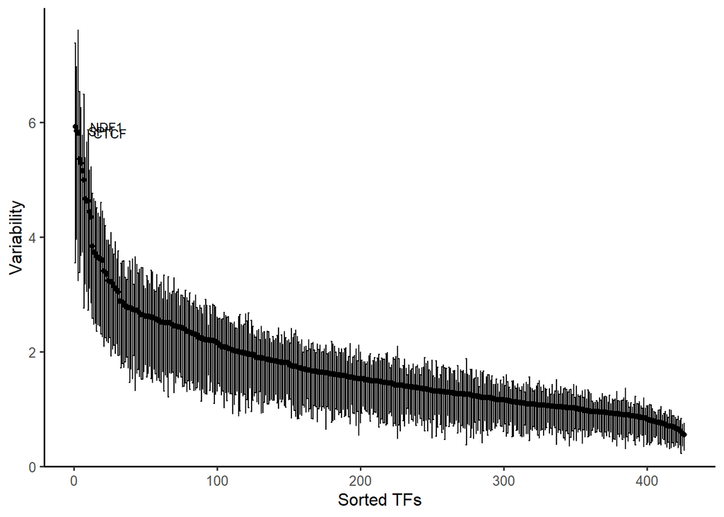

```r
variability <- computeVariability(dev)
plotVariability(variability)
```

```r
head(assays(dev)$z)
```

```
##                    Control_female_GSM6041841.bam Control_female_GSM6041842.bam
## AHR_MOUSE.H10MO.B                   -0.457514793                     0.1996005
## AIRE_MOUSE.H10MO.C                   0.005622139                    -0.3709105
## ALX1_MOUSE.H10MO.B                   0.587287072                     0.2338628
## ANDR_MOUSE.H10MO.B                  -5.870375989                    -2.0971566
## AP2A_MOUSE.H10MO.A                   0.310936349                    -1.9831591
## AP2B_MOUSE.H10MO.B                   2.049404480                    -0.4807225
##                    Control_female_GSM6041843.bam Control_male_GSM6041844.bam
## AHR_MOUSE.H10MO.B                      0.4333041                  -0.2488884
## AIRE_MOUSE.H10MO.C                    -2.4614330                   1.9510388
## ALX1_MOUSE.H10MO.B                    -0.2029508                  -0.3251826
## ANDR_MOUSE.H10MO.B                    -1.4262614                  -2.5597829
## AP2A_MOUSE.H10MO.A                    -0.3558144                   2.0256962
## AP2B_MOUSE.H10MO.B                    -1.1616743                   1.8065051
##                    Control_male_GSM6041845.bam Control_male_GSM6041846.bam
## AHR_MOUSE.H10MO.B                   0.63001452                 -0.69160203
## AIRE_MOUSE.H10MO.C                 -0.04200857                 -0.20568771
## ALX1_MOUSE.H10MO.B                  0.48786167                 -1.30988795
## ANDR_MOUSE.H10MO.B                 -3.28388716                 -4.38741658
## AP2A_MOUSE.H10MO.A                  1.60241566                  0.01668476
## AP2B_MOUSE.H10MO.B                 -1.02359573                  0.60201689
##                    FSS_female_GSM6041853.bam FSS_female_GSM6041854.bam
## AHR_MOUSE.H10MO.B                  0.8251211                -0.3026459
## AIRE_MOUSE.H10MO.C                 1.0545587                 1.4133526
## ALX1_MOUSE.H10MO.B                -0.7162339                 0.8307972
## ANDR_MOUSE.H10MO.B                 7.0379432                 0.1405143
## AP2A_MOUSE.H10MO.A                 1.1904692                -1.7722129
## AP2B_MOUSE.H10MO.B                 0.9150358                -0.3353169
##                    FSS_female_GSM6041855.bam FSS_male_GSM6041856.bam
## AHR_MOUSE.H10MO.B                 -1.2588803              -0.9613749
## AIRE_MOUSE.H10MO.C                 0.7441322               1.5818999
## ALX1_MOUSE.H10MO.B                 0.1066747               0.6714907
## ANDR_MOUSE.H10MO.B                 6.3499620               4.3032025
## AP2A_MOUSE.H10MO.A                 0.3973678               0.7159674
## AP2B_MOUSE.H10MO.B                 0.2718039               1.5442857
##                    FSS_male_GSM6041857.bam FSS_male_GSM6041858.bam
## AHR_MOUSE.H10MO.B                0.5143542              0.01301821
## AIRE_MOUSE.H10MO.C               1.4664436              0.28020707
## ALX1_MOUSE.H10MO.B              -0.3466341             -0.33339282
## ANDR_MOUSE.H10MO.B               6.1908392              4.72343884
## AP2A_MOUSE.H10MO.A               1.1145859             -0.16874044
## AP2B_MOUSE.H10MO.B               0.9151178             -0.54080762
```

```r
assays(dev)$norm <- scale(assays(dev)$z)
dev
```

```
## class: chromVARDeviations
## dim: 426 12
## metadata(0):
## assays(3): deviations z norm
## rownames(426): AHR_MOUSE.H10MO.B AIRE_MOUSE.H10MO.C ...
##   ZN148_MOUSE.H10MO.D ZN423_MOUSE.H10MO.D
## rowData names(3): name fractionMatches fractionBackgroundOverlap
## colnames(12): Control_female_GSM6041841.bam
##   Control_female_GSM6041842.bam ... FSS_male_GSM6041857.bam
##   FSS_male_GSM6041858.bam
## colData names(2): depth condition
```

```r
# differential analysis
dev$condition
```

```
##  [1] "F" "F" "F" "M" "M" "M" "F" "F" "F" "M" "M" "M"
```

```r
# if needed, we can specify the baseline condition, by default it's the first in alphabetical order
dev$condition <- factor(dev$condition)
mm <- model.matrix(~dev$condition)

fit <- eBayes(lmFit(assays(dev)$norm, mm))
res <- as.data.frame(topTable(fit, coef="dev$conditionM", number = Inf))
head(res)
```

```
##                         logFC     AveExpr          t      P.Value    adj.P.Val
## TYY1_MOUSE.H10MO.A  -5.357270 -0.21036064 -10.428141 2.606175e-08 1.110230e-05
## TEAD1_MOUSE.H10MO.D -4.410020 -0.14726828  -9.828443 5.733065e-08 1.221143e-05
## RUNX3_MOUSE.H10MO.B -2.372881 -0.15355971  -8.093270 6.966563e-07 9.892519e-05
## MYB_MOUSE.H10MO.C   -2.374547 -0.25401199  -6.741280 6.288420e-06 6.697167e-04
## ZN143_MOUSE.H10MO.D -2.209931  0.06881209  -5.523911 5.631010e-05 4.797621e-03
## PTF1A_MOUSE.H10MO.C -1.831119 -0.21092531  -5.076510 1.324875e-04 9.406615e-03
##                            B
## TYY1_MOUSE.H10MO.A  9.460557
## TEAD1_MOUSE.H10MO.D 8.711952
## RUNX3_MOUSE.H10MO.B 6.299483
## MYB_MOUSE.H10MO.C   4.136420
## ZN143_MOUSE.H10MO.D 1.962170
## PTF1A_MOUSE.H10MO.C 1.112003
```

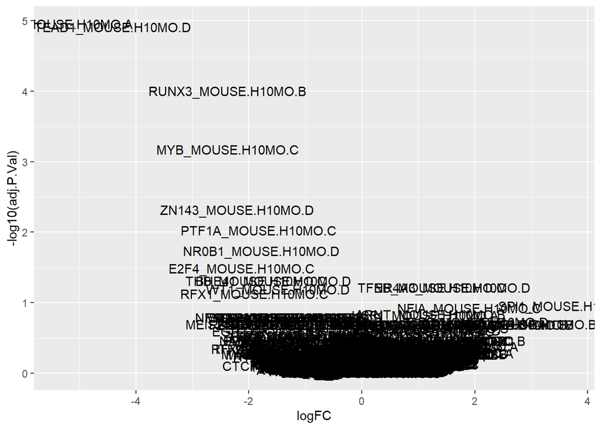

```r
res$TF <- row.names(res)
ggplot(res, aes(logFC, -log10(adj.P.Val), label=TF)) + geom_text()
```

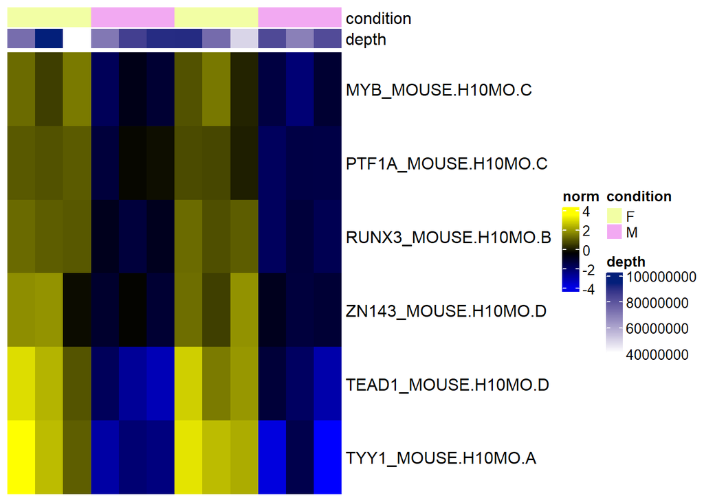

```r
sechm(dev, features = head(row.names(res)), assayName="norm", top_annotation = c("condition", "depth"))
```

# For each analysis, report the top most significant motifs, plot a heatmap of the normalized accessibility scores across the samples for those motifs, and write a short paragraph interpreting the results.

## comparing male and female animals

# There I tried to do both analyses in the same test (should be better statistically)

```r
genome <- BSgenome.Mmusculus.UCSC.mm10::BSgenome.Mmusculus.UCSC.mm10 # because I had windows-related problems with the other genome
seqlevelsStyle(peak_counts_SE) = "UCSC"
se <- suppressWarnings(chromVAR::addGCBias(peak_counts_SE, genome=genome))
moi <- suppressWarnings(motifmatchr::matchMotifs(motifs, subject=se, genome=genome))

se
```

```
## class: RangedSummarizedExperiment
## dim: 20660 12
## metadata(0):
## assays(1): counts
## rownames: NULL
## rowData names(1): bias
## colnames(12): Control_female_GSM6041841.bam
##   Control_female_GSM6041842.bam ... FSS_male_GSM6041857.bam
##   FSS_male_GSM6041858.bam
## colData names(1): depth
```

```r
colData(se)$sex <- c("F","F","F","M","M","M","F","F","F","M","M","M")
se$sex <- c("F","F","F","M","M","M","F","F","F","M","M","M")
colData(se)$condition <- c("CTRL","CTRL","CTRL","CTRL","CTRL","CTRL","FSS","FSS","FSS","FSS","FSS","FSS")
se$condition <- c("CTRL","CTRL","CTRL","CTRL","CTRL","CTRL","FSS","FSS","FSS","FSS","FSS","FSS")
colData(se)
```

```
## DataFrame with 12 rows and 3 columns
##                                   depth         sex   condition
##                               <numeric> <character> <character>
## Control_female_GSM6041841.bam  73170149           F        CTRL
## Control_female_GSM6041842.bam  93995034           F        CTRL
## Control_female_GSM6041843.bam  40167775           F        CTRL
## Control_male_GSM6041844.bam    70491005           M        CTRL
## Control_male_GSM6041845.bam    84985977           M        CTRL
## ...                                 ...         ...         ...
## FSS_female_GSM6041854.bam      73674456           F         FSS
## FSS_female_GSM6041855.bam      49285912           F         FSS
## FSS_male_GSM6041856.bam        82385764           M         FSS
## FSS_male_GSM6041857.bam        68623011           M         FSS
## FSS_male_GSM6041858.bam        81801232           M         FSS
```

```r
rowRanges(se)$test <- 3
rowRanges(se)
```

```
## GRanges object with 20660 ranges and 2 metadata columns:
##           seqnames            ranges strand |      bias      test
##              <Rle>         <IRanges>  <Rle> | <numeric> <numeric>
##       [1]     chr1   3012609-3012858      * |     0.348         3
##       [2]     chr1   3094941-3095190      * |     0.424         3
##       [3]     chr1   3113634-3113883      * |     0.448         3
##       [4]     chr1   3119522-3119771      * |     0.448         3
##       [5]     chr1   3119880-3120129      * |     0.432         3
##       ...      ...               ...    ... .       ...       ...
##   [20656]     chrY 90744317-90744566      * |     0.636         3
##   [20657]     chrY 90744689-90744938      * |     0.544         3
##   [20658]     chrY 90761326-90761575      * |     0.640         3
##   [20659]     chrY 90804984-90805233      * |     0.472         3
##   [20660]     chrY 90808700-90808949      * |     0.416         3
##   -------
##   seqinfo: 30 sequences from an unspecified genome; no seqlengths
```

```r
#moi <- motifmatchr::matchMotifs(motifs, subject=peak_counts_SE, genome=genome_fa)
dev <- chromVAR::computeDeviations(object = se, annotations=moi,
                                   background_peaks=getBackgroundPeaks(se, niterations=1000))
dev
```

```
## class: chromVARDeviations
## dim: 426 12
## metadata(0):
## assays(2): deviations z
## rownames(426): AHR_MOUSE.H10MO.B AIRE_MOUSE.H10MO.C ...
##   ZN148_MOUSE.H10MO.D ZN423_MOUSE.H10MO.D
## rowData names(3): name fractionMatches fractionBackgroundOverlap
## colnames(12): Control_female_GSM6041841.bam
##   Control_female_GSM6041842.bam ... FSS_male_GSM6041857.bam
##   FSS_male_GSM6041858.bam
## colData names(3): depth sex condition
```

```r
colData(dev)
```

```
## DataFrame with 12 rows and 3 columns
##                                   depth         sex   condition
##                               <numeric> <character> <character>
## Control_female_GSM6041841.bam  73170149           F        CTRL
## Control_female_GSM6041842.bam  93995034           F        CTRL
## Control_female_GSM6041843.bam  40167775           F        CTRL
## Control_male_GSM6041844.bam    70491005           M        CTRL
## Control_male_GSM6041845.bam    84985977           M        CTRL
## ...                                 ...         ...         ...
## FSS_female_GSM6041854.bam      73674456           F         FSS
## FSS_female_GSM6041855.bam      49285912           F         FSS
## FSS_male_GSM6041856.bam        82385764           M         FSS
## FSS_male_GSM6041857.bam        68623011           M         FSS
## FSS_male_GSM6041858.bam        81801232           M         FSS
```

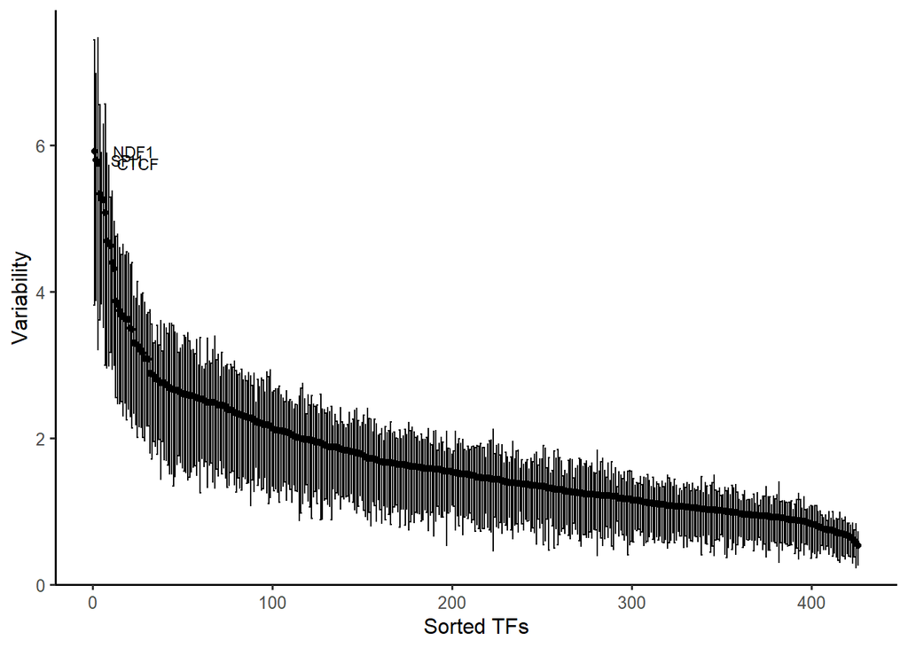

```r
variability <- computeVariability(dev)
plotVariability(variability)
```

```r
head(assays(dev)$z)
```

```
##                    Control_female_GSM6041841.bam Control_female_GSM6041842.bam
## AHR_MOUSE.H10MO.B                   -0.472518622                     0.1938201
## AIRE_MOUSE.H10MO.C                  -0.003331737                    -0.4776931
## ALX1_MOUSE.H10MO.B                   0.667995226                     0.2242113
## ANDR_MOUSE.H10MO.B                  -5.982046452                    -2.1046085
## AP2A_MOUSE.H10MO.A                   0.344164702                    -1.9622446
## AP2B_MOUSE.H10MO.B                   2.092677475                    -0.5408225
##                    Control_female_GSM6041843.bam Control_male_GSM6041844.bam
## AHR_MOUSE.H10MO.B                      0.4065171                  -0.3069747
## AIRE_MOUSE.H10MO.C                    -2.4415851                   2.0085451
## ALX1_MOUSE.H10MO.B                    -0.2558072                  -0.3429013
## ANDR_MOUSE.H10MO.B                    -1.3948535                  -2.5527731
## AP2A_MOUSE.H10MO.A                    -0.3496438                   2.2053722
## AP2B_MOUSE.H10MO.B                    -1.1740698                   1.7939311
##                    Control_male_GSM6041845.bam Control_male_GSM6041846.bam
## AHR_MOUSE.H10MO.B                  0.654430750                 -0.69863998
## AIRE_MOUSE.H10MO.C                -0.006100764                 -0.24652200
## ALX1_MOUSE.H10MO.B                 0.497151587                 -1.28645648
## ANDR_MOUSE.H10MO.B                -3.316613462                 -4.51287922
## AP2A_MOUSE.H10MO.A                 1.536096593                 -0.05496926
## AP2B_MOUSE.H10MO.B                -1.094119620                  0.59225127
##                    FSS_female_GSM6041853.bam FSS_female_GSM6041854.bam
## AHR_MOUSE.H10MO.B                  0.8432707                -0.3076952
## AIRE_MOUSE.H10MO.C                 0.9261470                 1.4690734
## ALX1_MOUSE.H10MO.B                -0.6886578                 0.8268759
## ANDR_MOUSE.H10MO.B                 6.9345468                 0.2035494
## AP2A_MOUSE.H10MO.A                 1.1844326                -1.7376487
## AP2B_MOUSE.H10MO.B                 0.8902104                -0.2946589
##                    FSS_female_GSM6041855.bam FSS_male_GSM6041856.bam
## AHR_MOUSE.H10MO.B                 -1.2940916              -1.0080115
## AIRE_MOUSE.H10MO.C                 0.7137814               1.6254900
## ALX1_MOUSE.H10MO.B                 0.1948291               0.7712942
## ANDR_MOUSE.H10MO.B                 5.9988078               4.4748521
## AP2A_MOUSE.H10MO.A                 0.4147544               0.6343916
## AP2B_MOUSE.H10MO.B                 0.2138896               1.5067047
##                    FSS_male_GSM6041857.bam FSS_male_GSM6041858.bam
## AHR_MOUSE.H10MO.B                0.5561630             0.001544589
## AIRE_MOUSE.H10MO.C               1.4471688             0.275837926
## ALX1_MOUSE.H10MO.B              -0.3007884            -0.320605192
## ANDR_MOUSE.H10MO.B               5.9718000             4.668847776
## AP2A_MOUSE.H10MO.A               1.1775784            -0.138984847
## AP2B_MOUSE.H10MO.B               0.9048979            -0.579917481
```

```r
assays(dev)$norm <- scale(assays(dev)$z)
dev
```

```
## class: chromVARDeviations
## dim: 426 12
## metadata(0):
## assays(3): deviations z norm
## rownames(426): AHR_MOUSE.H10MO.B AIRE_MOUSE.H10MO.C ...
##   ZN148_MOUSE.H10MO.D ZN423_MOUSE.H10MO.D
## rowData names(3): name fractionMatches fractionBackgroundOverlap
## colnames(12): Control_female_GSM6041841.bam
##   Control_female_GSM6041842.bam ... FSS_male_GSM6041857.bam
##   FSS_male_GSM6041858.bam
## colData names(3): depth sex condition
```

```r
# differential analysis
dev$condition
```

```
##  [1] "CTRL" "CTRL" "CTRL" "CTRL" "CTRL" "CTRL" "FSS"  "FSS"  "FSS"  "FSS"
## [11] "FSS"  "FSS"
```

```r
dev$sex
```

```
##  [1] "F" "F" "F" "M" "M" "M" "F" "F" "F" "M" "M" "M"
```

```r
# if needed, we can specify the baseline condition, by default it's the first in alphabetical order
dev$condition <- factor(dev$condition)
dev$condition <- relevel(dev$condition, "CTRL")
dev$sex <- factor(dev$sex)
mm <- model.matrix(~dev$condition+dev$sex)

fit <- eBayes(lmFit(assays(dev)$norm, mm))
res_c <- as.data.frame(topTable(fit, coef="dev$conditionFSS", number = Inf))
head(res_c)
```

```
##                          logFC     AveExpr         t      P.Value   adj.P.Val
## ANDR_MOUSE.H10MO.B   4.3325754  0.34890346  6.951219 6.169513e-06 0.002628213
## GCR_MOUSE.H10MO.C    2.8816414  0.34035718  6.011010 2.976476e-05 0.006339894
## PRGR_MOUSE.H10MO.C   1.9428757  0.05373220  3.331055 4.849368e-03 0.688610297
## MSX2_MOUSE.H10MO.D   1.0773218  0.09934175  2.906950 1.132263e-02 0.996391221
## NR1I3_MOUSE.H10MO.S  0.8208350  0.11997247  2.706389 1.684434e-02 0.996391221
## BHE41_MOUSE.H10MO.D -0.8796747 -0.24172751 -2.599128 2.079400e-02 0.996391221
##                             B
## ANDR_MOUSE.H10MO.B   3.985516
## GCR_MOUSE.H10MO.C    2.620380
## PRGR_MOUSE.H10MO.C  -1.992747
## MSX2_MOUSE.H10MO.D  -2.764155
## NR1I3_MOUSE.H10MO.S -3.122405
## BHE41_MOUSE.H10MO.D -3.311224
```

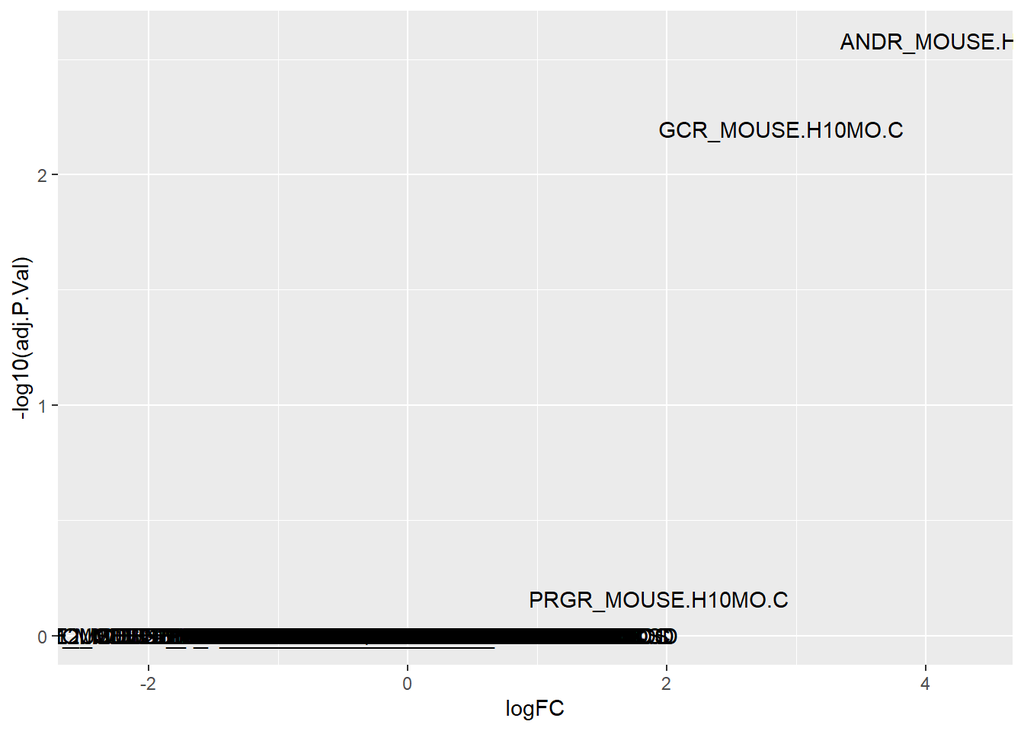

```r
res_c$TF <- row.names(res_c)
ggplot(res_c, aes(logFC, -log10(adj.P.Val), label=TF)) + geom_text()
```